# Estudo R for Data Science - Cap 2

#### Exercícios 3.6.1:

**1. What geom would you use to draw a line chart? A boxplot? A histogram? An area chart?**

**Resposta :** line chart : geom_line() boxplot : geom_boxplot() histogram: geom_histogram() area chart: geom_area()

**Run this code in your head and predict what the output will look like. Then, run the code in R and check your predictions.**

**Resposta :** Na parte global irá criar um gráfico com x e y destacando cores por drv, adicionado um scatterplot e um smooth. *So depois de rodar que identifiquei que o se=FALSE removeu o intervalo de confiança do smooth*

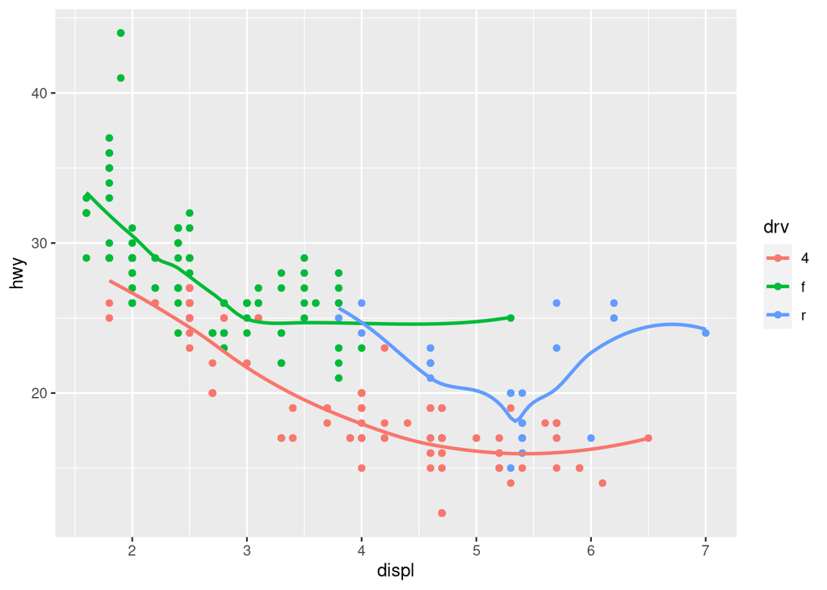

```r
ggplot(data = mpg, mapping = aes(x = displ, y = hwy, color = drv)) +
  geom_point() +
  geom_smooth(se = FALSE)
```

**3. What does show.legend = FALSE do? What happens if you remove it? Why do you think I used it earlier in the chapter?** **Resposta :** remove e legenda, se remoer irá criar uma legenda.

**4. What does the se argument to geom_smooth() do?**

**Resposta :** Habilita ou não o intervalo de confiança no gráfico

**5. Will these two graphs look different? Why/why not?** **Resposta** : O resultado será o mesmo, mas com informação duplicada

```r
ggplot(data = mpg, mapping = aes(x = displ, y = hwy)) +
  geom_point() +
  geom_smooth()
ggplot() +
  geom_point(data = mpg, mapping = aes(x = displ, y = hwy)) +
  geom_smooth(data = mpg, mapping = aes(x = displ, y = hwy))
```

[output not shown]

## Referências e Links :

- [ggplot galery](https://exts.ggplot2.tidyverse.org/gallery/)